# Introduction to running Waterbear

Waterbear is a Bayesian method to infer CRISPR effects in pooled FACS screens. Due to its dependency on NIMBLE for the MCMC sampling, there are a few conceptual steps:

1. Load the data.
2. Make a Waterbear object
3. Run some NIMBLE boilerplate to compile your model.
4. Sample from using MCMC (NIMBLE). This is the main, time-consuming step which infers all of the distributions.
5. Analyze the results.

```r
library('waterbear')
library('dplyr')
```

```r
library('tidyr')
library('stringr')
library('ggplot2')
theme_set(theme_classic())
```

## Load the data

Ultimately, what Waterbear expects is a 3-dimensional array where dimension one is replicate, two is guide, and three is the bin. This kind of datastructure is a bit clunky, and thus we provide some helper functions. In particular, your alignments might come in the MaGeCK-style format, where the columns are in the following order:

1. `sgRNA`, a unique character label of that guide.
2. `Gene`, a repeated character label of the corresponding gene that guide is targetting.
3. `SAMPLE_LABEL_1`, the actual (raw) counts corresponding to the first sample
4. `...`, more samples

Let’s start by loading one of the files from the package:

```r
raw_counts = read.table(
  system.file('extdata','high_low_MOI_screens_D1_D2_D3_2022-04-23.count.txt',
    package = 'waterbear'),
  header = TRUE, stringsAsFactors = FALSE, sep = '\t')
head(raw_counts[, 1:10])
```

```
#>    sgRNA   Gene TF_lib_plasmid High_Coverage_High_MOI_D1_GFP
#> 1 s_3738 ZNF350          31902                          5582
#> 2 s_1493   PAX9          21328                          3848
#> 3 s_1353   NFE2          14376                          2027
#> 4 s_4305 ZNF561          11703                          1912
#> 5 s_5218   LHX8          14594                          2258
#> 6 s_3200  GMEB2          17236                          2985
#>   High_Coverage_High_MOI_D1_Q1 High_Coverage_High_MOI_D1_Q2
#> 1                         5272                         7063
#> 2                         4114                         4903
#> 3                         1873                         2697
#> 4                         2045                         2703
#> 5                         2367                         3038
#> 6                         3475                         4182
#>   High_Coverage_High_MOI_D1_Q3 High_Coverage_High_MOI_D1_Q4
#> 1                         5896                         6717
#> 2                         4281                         5999
#> 3                         2375                         2526
#> 4                         1869                         2172
#> 5                         2697                         3095
#> 6                         2643                         4031
#>   High_Coverage_High_MOI_D2_GFP High_Coverage_High_MOI_D2_Q1
#> 1                          5095                         3661
#> 2                          3903                         2888
#> 3                          1543                         1544
#> 4                          1664                         1632
#> 5                          2512                         2408
#> 6                          2793                         2106
```

Great. Data is as expected. The next thing we need to do is create a metadata data.frame describing each column. If you note, the columns have the suffix `DX_QY` where X represents the replicate and Y represents the bin. This experiment samples from all four bins, so there is no unobserved data. Let’s now make the sample mapping data.frame

```r
c_name = grep('Low_Coverage_High_MOI', colnames(raw_counts), value = TRUE)
sample_mapping = data.frame(c_name = c_name)
sample_mapping = mutate(sample_mapping, sample = str_extract(c_name, 'D1|D2|D3'))
sample_mapping = mutate(sample_mapping, bin = str_extract(c_name, 'Q[1-4]'))
head(sample_mapping)
```

```
#>                        c_name sample bin
#> 1 Low_Coverage_High_MOI_D1_Q1     D1  Q1
#> 2 Low_Coverage_High_MOI_D1_Q2     D1  Q2
#> 3 Low_Coverage_High_MOI_D1_Q3     D1  Q3
#> 4 Low_Coverage_High_MOI_D1_Q4     D1  Q4
#> 5 Low_Coverage_High_MOI_D2_Q1     D2  Q1
#> 6 Low_Coverage_High_MOI_D2_Q2     D2  Q2
```

Note, you see that we have one row corresponding to each column in the `raw_counts` data.frame.

The final thing we need to create a Waterbear style data array is the ordering of the bins. **This is a crucial step**. In particular, if the ordering is incorrect, you will end up with improper inferences. The order is from “low” to “high” in bins.

```r
ordering = c('Q1', 'Q2', 'Q3', 'Q4')
```

With these three objects, we can now make a Waterbear array.

```r
wb_array = wb_counts_to_array(raw_counts, sample_mapping, ordering)
```

Note: if your data is not in the MaGeCK-style format already, you can simply jump to the wb_array style format. as noted at the beginning of this section. Some examples of what the data might look like is as follows.

Replicate 1, the first 5 guides:

```r
wb_array[1, 1:5, ]
```

```
#>          Q1   Q2   Q3   Q4
#> s_3738 6736 9733 6770 6615
#> s_1493 4744 7244 5098 7353
#> s_1353 1782 3414 2570 2704
#> s_4305 2211 3828 2765 1840
#> s_5218 2352 4631 2715 2305
```

Note the bins are ordered according to the specified ordering

All three replicates across the first five guides, only the first bin:

```r
wb_array[, 1:5, 1]
```

```
#>    s_3738 s_1493 s_1353 s_4305 s_5218
#> D1   6736   4744   1782   2211   2352
#> D2   3974   3560   2434   1371   3155
#> D3   6847   5258   2612   3282   2067
```

## Waterbear object initialization

Now that we have our data, we can make a simple Waterbear object.

One thing we need is a guide to gene mapping. We can get this from the `raw_counts` data:

```r
gene_mapping = raw_counts[, c('sgRNA', 'Gene')]
colnames(gene_mapping) = c('guide', 'gene')
head(gene_mapping)
```

```
#>    guide   gene
#> 1 s_3738 ZNF350
#> 2 s_1493   PAX9
#> 3 s_1353   NFE2
#> 4 s_4305 ZNF561
#> 5 s_5218   LHX8
#> 6 s_3200  GMEB2
```

```r
wo = wb_make_object(wb_array, gene_mapping, bin_size_prior = c(0.2, 0.3, 0.3, 0.2))
```

Note the final vector. This is the expected bin size prior. That is, in bin 3, we expect 0.30 of the mass. This prior isn’t super important, as the tool will dynamically learn the bin configuration for each sample. A simple ballpark estimate is fine.

Next, we find some reasonable starting parameters using likelihood estimation for most of the model:

```r
wo = wb_em_start(wo)
```

```
#> estimating bin sizes
#> ..........
#> estimating guide and gene level effects
#> ranking based on likelihood ratio
```

We are ready for the next step.

## Some NIMBLE boilerplate

First, we need to load the NIMBLE models into the global namespace. A little unconventional, I know.

```r
source(system.file('nimble.R', package = 'waterbear'))
```

There are a few different types of models we can implement, but the most common will likely be the `sample_specific_disperison_model`.

```r
n_model = nimbleModel(sample_specific_dispersion_model,
                      data = wo$data, constants = wo$const, inits = wo$init)
```

```
#> Defining model
#>   [Note] 'guide_index' is provided in 'constants' but not used in the model code and is being ignored.
#>   [Note] 'order' is provided in 'constants' but not used in the model code and is being ignored.
#>   [Note] 'nt_index' is provided in 'constants' but not used in the model code and is being ignored.
#>   [Note] Registering 'ddirchmulti' as a distribution based on its use in BUGS code. If you make changes to the nimbleFunctions for the distribution, you must call 'deregisterDistributions' before using the distribution in BUGS code for those changes to take effect.
#> Building model
#> Setting data and initial values
#> Running calculate on model
#>   [Note] Any error reports that follow may simply reflect missing values in model variables.
#> Checking model sizes and dimensions
#>   [Note] This model is not fully initialized. This is not an error.
#>          To see which variables are not initialized, use model$initializeInfo().
#>          For more information on model initialization, see help(modelInitialization).
```

Next, configure the sampler. You won’t need every parameter listed, but sometimes it’s helpful to save them and look at them later.

```r
n_configuration = configureMCMC(n_model)
```

```
#> ===== Monitors =====
#> thin = 1: bin_alpha, dispersion, psi, sigma_gene, sigma_guide
#> ===== Samplers =====
#> RW_dirichlet sampler (3)
#>   - bin_alpha[1, 1:4]
#>   - bin_alpha[2, 1:4]
#>   - bin_alpha[3, 1:4]
#> RW sampler (5413)
#>   - dispersion
#>   - sigma_gene
#>   - sigma_guide
#>   - sample_dispersion[]  (3 elements)
#>   - guide_shift[]  (5407 elements)
#> conjugate sampler (1351)
#>   - psi
#>   - gene_shift[]  (1350 elements)
#> binary sampler (1350)
#>   - gene_inclusion[]  (1350 elements)
```

```r
n_configuration$addMonitors(
  c('gene_inclusion',
    'total_shift',
    'guide_shift',
    'gene_shift',
    'dispersion',
    'sample_dispersion',
    'psi'
  ))
```

```
#> thin = 1: bin_alpha, dispersion, gene_inclusion, gene_shift, guide_shift, psi, sample_dispersion, sigma_gene, sigma_guide, total_shift
```

Finally, compile to C++

```r
n_mcmc_build = buildMCMC(n_configuration)
C_n_model = compileNimble(n_model)
C_n_mcmc = compileNimble(n_mcmc_build, project = n_model, showCompilerOutput = TRUE)
```

We are ready to run our sampler!

**Note:** we recognize this is currently a bit of a mess. We are currently working on a different sampler that is much faster and will not requires some of these workarounds. See branch `gibbs`.

## Generate some samples

There are some choices to make here. Generally speaking, the following are pretty sane defaults. If you want your results to be reproducible, make sure to set a seed.

```r
n_samples = 10000
n_burnin = 5000
n_chains = 4
seed = 42
system.time({
  wb_samples = runMCMC(
    C_n_mcmc, niter = n_samples, nburnin = n_burnin,
    nchains = n_chains,
    setSeed = seed,
    summary = TRUE)
})
```

Now you sit and wait. On our cluster with one CPU this takes about 3.5 hours.

## Analyze the results

With your raw posteriors in `wb_samples`, you can now analyze the results.

```r
guide_summaries = wb_guide_summaries(wo, wb_samples)
```

From here, we can see some helpful summaries across the guide and gene level. Here, we can see the largest overall guide level effects.

```r
arrange(guide_summaries$guides, desc(abs(Mean))) %>%
  head()
```

```
#>            variable       Mean     Median    St.Dev. X95.CI_low X95.CI_upp
#> 1 guide_shift[4480] -1.3142320 -1.3136023 0.06157039 -1.4372813 -1.1951903
#> 2 guide_shift[1449] -1.3132975 -1.3131648 0.06430059 -1.4409149 -1.1897137
#> 3 guide_shift[1927]  0.9818336  0.9804705 0.05862187  0.8693174  1.1007790
#> 4  guide_shift[575] -0.9718335 -0.9717741 0.07537960 -1.1188887 -0.8260605
#> 5  guide_shift[803]  0.9503652  0.9497621 0.06248343  0.8285349  1.0712160
#> 6 guide_shift[4973]  0.9150254  0.9145014 0.06969911  0.7776567  1.0534142
#>   wb_guide_index guide_data_index  guide  gene mapping
#> 1           4480             4959  s_994 IL2RA     440
#> 2           1449             1596  s_995 IL2RA     440
#> 3           1927             2113 s_2770 MED12     535
#> 4            575              639  s_993 IL2RA     440
#> 5            803              885  s_134  CBFB      78
#> 6           4973             5502 s_5367  DUX4     166
```

For gene-level local false sign rate and related statistics, use the following function:

```r
lfsr_level = 0.05
gene_posterior_summary = wb_gene_posterior_mass(wo, wb_samples, lfsr_level)
```

```r
arrange(gene_posterior_summary, lfsr, desc(abs(mu))) %>%
  head()
```

```
#>        lower      upper gt0 lt0         mu   gene lfsr
#> 1 -1.1468088 -0.8862089   0   1 -1.0163217  IL2RA    0
#> 2  0.6406655  0.8873007   1   0  0.7645037  MED12    0
#> 3 -0.8622919 -0.6158802   0   1 -0.7381584 STAT5B    0
#> 4  0.5280649  0.7782605   1   0  0.6535763   CBFB    0
#> 5  0.4645822  0.7130363   1   0  0.5886603    MYB    0
#> 6  0.4006949  0.6442840   1   0  0.5224211   KLF2    0
```

There are the genes we are most confident in with their corresponding `1 - lfsr` credibility interval.

## Make some plots

Now, we can start making some pretty plots. First, we might want to look at the top hits to see their gene-level posterior.

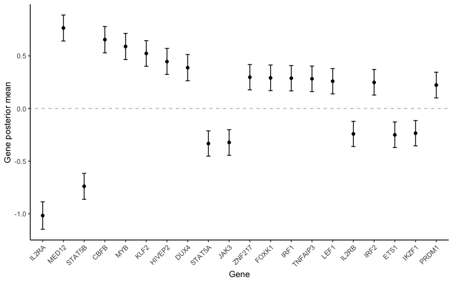

```r
# rearrange such that the greatest hits are on the top
gene_posterior_summary = arrange(gene_posterior_summary, lfsr, desc(abs(mu)))
gene_posterior_summary = mutate(gene_posterior_summary, plot_order = factor(gene, levels = gene))

# plot the top 20
p = ggplot(
  head(gene_posterior_summary, 20), aes(plot_order, mu))
p = p + geom_point()
p = p + geom_errorbar(aes(ymin = lower, ymax = upper), width = 0.2)
p = p + geom_abline(intercept = 0, slope = 0, color = 'gray', linetype = 2)
p = p + theme(axis.text.x = element_text(angle = 45,  hjust=1))
p = p + xlab('Gene')
p = p + ylab('Gene posterior mean')
p
```

We can also look at arbitrary genes like this:

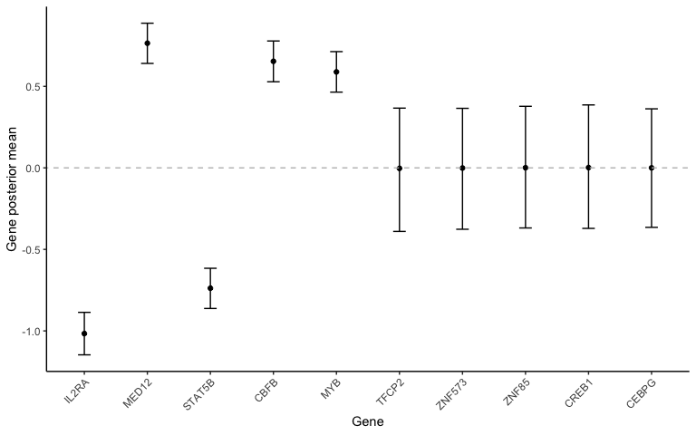

```r
p = ggplot(
  bind_rows(
    head(gene_posterior_summary, 5),
    tail(gene_posterior_summary, 5)
  ),
  aes(plot_order, mu))
p = p + geom_point()
p = p + geom_errorbar(aes(ymin = lower, ymax = upper), width = 0.2)
p = p + geom_abline(intercept = 0, slope = 0, color = 'gray', linetype = 2)
p = p + theme(axis.text.x = element_text(angle = 45,  hjust=1))
p = p + xlab('Gene')
p = p + ylab('Gene posterior mean')
p
```

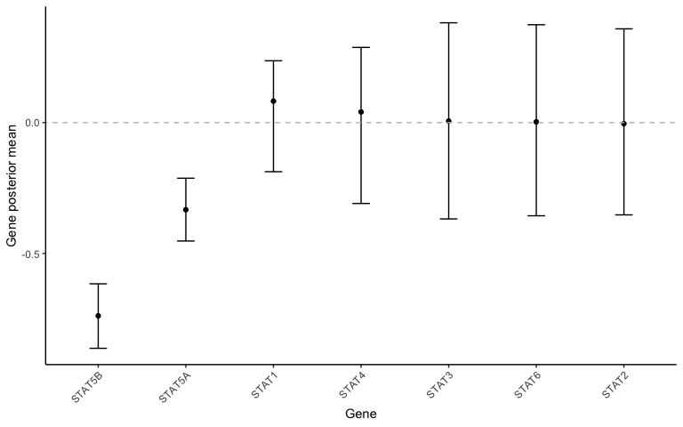

```r
p = ggplot(
  filter(gene_posterior_summary, grepl('stat', gene, ignore.case = TRUE)),
  aes(plot_order, mu))
p = p + geom_point()
p = p + geom_errorbar(aes(ymin = lower, ymax = upper), width = 0.2)
p = p + geom_abline(intercept = 0, slope = 0, color = 'gray', linetype = 2)
p = p + theme(axis.text.x = element_text(angle = 45,  hjust=1))
p = p + xlab('Gene')
p = p + ylab('Gene posterior mean')
p
```

## Accessing posterior samples

You can access the posterior samples in a decently structured way using `wb_get_posterior`.

Right now, it can return guide level effects, gene level effects, and the gene level posterior inclusion probability.

```r
gene_effect = wb_get_posterior(wo, wb_samples, 'gene')
head(gene_effect[, 1:10])
```

```
#>               [,1]        [,2]        [,3]        [,4]        [,5]
#> ABCF1  -0.22255267 -0.18088317 -0.01767407 -0.10887084 -0.07142761
#> AGER    0.08563010  0.11716444  0.05600668  0.15191696  0.10527480
#> AGPAT1 -0.01716369 -0.15976023 -0.08502418 -0.17673634 -0.23674620
#> AHR    -0.05406700 -0.02056964  0.00465851 -0.14196693 -0.16139489
#> AHRR   -0.21608003 -0.14475123 -0.26593093 -0.30723491 -0.18068651
#> AIF1   -0.10323773  0.01028528 -0.11093697  0.03004654 -0.02352005
#>                 [,6]         [,7]        [,8]         [,9]        [,10]
#> ABCF1  -0.1020267240 -0.081923120 -0.09215689 -0.167970467 -0.164384493
#> AGER    0.0051329846 -0.008743465  0.06714834 -0.001601561 -0.008828391
#> AGPAT1 -0.0962354320 -0.097324838 -0.12140337 -0.194110052 -0.191203539
#> AHR    -0.0903444911 -0.169975508 -0.16705590 -0.202371605 -0.138715924
#> AHRR   -0.2164446199 -0.084473387 -0.13239729 -0.075245447  0.002685142
#> AIF1    0.0003759855  0.073053613 -0.07980767 -0.035028364 -0.042365561
```

# A note on control guides

Waterbear will attempt to find control guides in your guide-list by searching for guides with the string `Non-` somewhere in the name. This can be adjusted during `wb_make_object()` stage with the argument `control_guide_regex`. If you do not have any controls in the experiment, this parameter should be `NA` or `NULL`.

Additionally, when initializing parameters, Waterbear will use a random set of guides to estimate the dispersion in the `wb_em_start()` function. The number of guides it will randomly choose is in the parameter `n_random_guides`. If there are guides that were found in the `wb_make_object()` stage, then `n_random_guides` will not be used.

Finally, the standard model `sample_specific_dispersion_model` CANNOT be used. This model uses the control guides in the model to estimate the dispersion. You can use `sample_specific_dispersion_model_no_controls`.

In summary, here are changes,

```r
# to make the object
wo = wb_make_object(wb_array, gene_mapping, bin_size_prior = c(0.2, 0.3, 0.3, 0.2),
  control_guide_regex = NA)

# no actual changes necessary, but can change the number of random guides
wo = wb_em_start(wo, n_random_guides = 1000)

# make sure to specify the no controls model
n_model = nimbleModel(sample_specific_dispersion_model_no_controls,
                      data = wo$data, constants = wo$const, inits = wo$init)
```